# Red Wine Quality Project

# Multivariate Plots Section

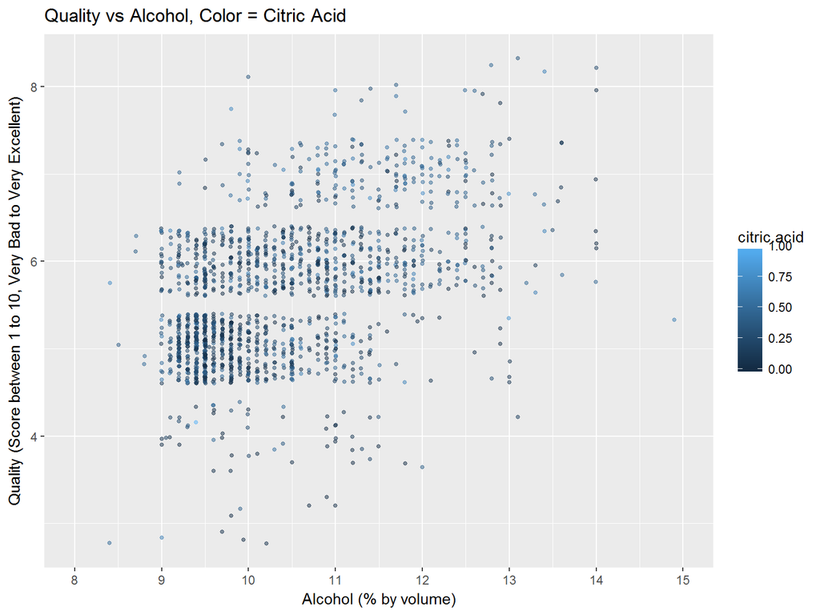

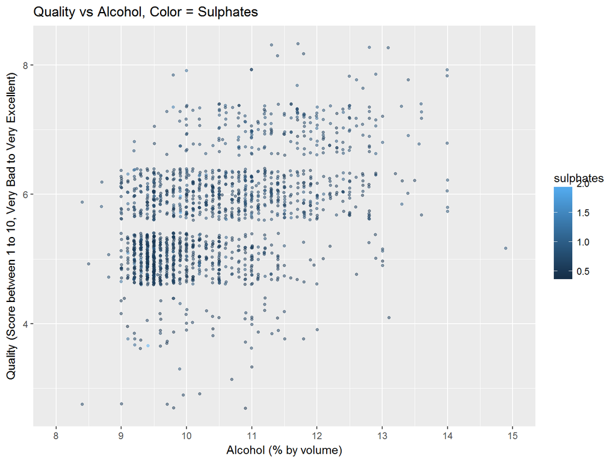

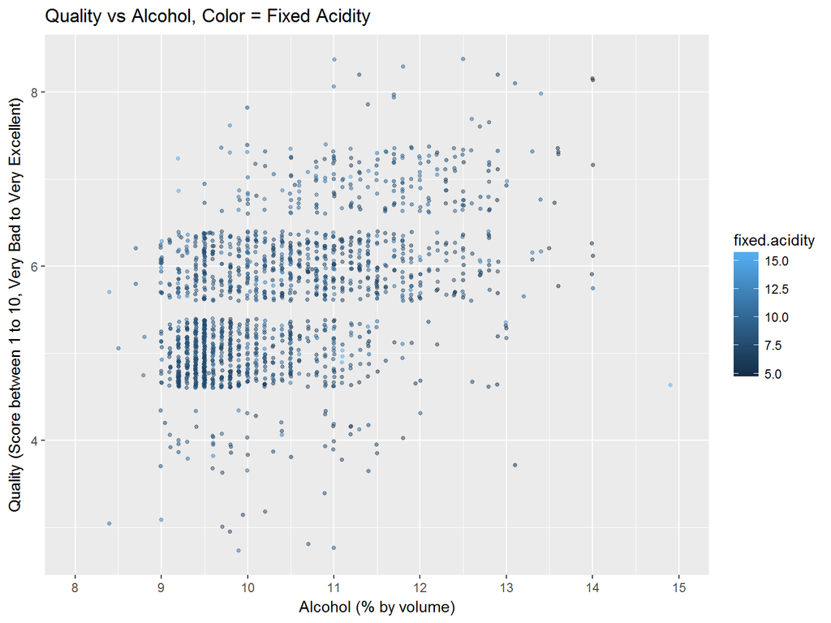

[figure not shown]

# Multivariate Analysis

### Talk about some of the relationships you observed in this part of the investigation. Were there features that strengthened each other in terms of looking at your feature(s) of interest?

Based on the data and plots, it seems that to maintain a red wine quality of 8, the below variables will need to be at:

- Residual Sugar: 1.40 to 6.40
- Fixed Acidity: 5 to 12.6
- Sulphates: 0.63 to 1.10
- Citric Acid: 0.03 to 0.72
- Alcohol: 9.8 to 14.0

There seems to be a range for the variables where they are able to affect the red wines’ quality to 8. Adding additional amounts does not affect it further.

Besides the variable ranges, the below average values should also result in quality 8 red wines:

- Average Residual Sugar level: 2.578
- Average Fixed Acidity Level: 8.567
- Average Sulphates Level: 0.7678
- Average Citric Acid Level: 0.3911
- Average Alcohol %: 12.09

However as quality is a subjective evaluation (Based on personal preference), it will be hard to say for certain that increasing certain variables will increase quality.

### Were there any interesting or surprising interactions between features?

The range which the variables affect quality varies widely, supporting the notion that there is no standard measure of quality and it is based purely on the taste of the person evaluating them.

### OPTIONAL: Did you create any models with your dataset? Discuss the strengths and limitations of your model.

No models were created as quality is based on personal opinion hence, it would be hard to produce a prediction that increasing x will definitely increase quality.

# Final Plots and Summary

### Plot One

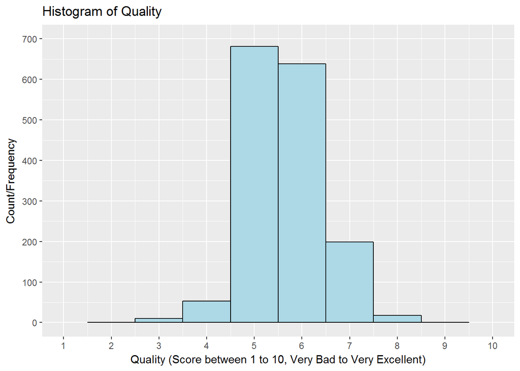

### Description One

Distribution of quality appears to be near normal with most deciding on 5 and 6. As the graders were expers, we can assume that majority of the red wines are ok/average however, it is important to take note that the gradings are of personal perference.

### Plot Two

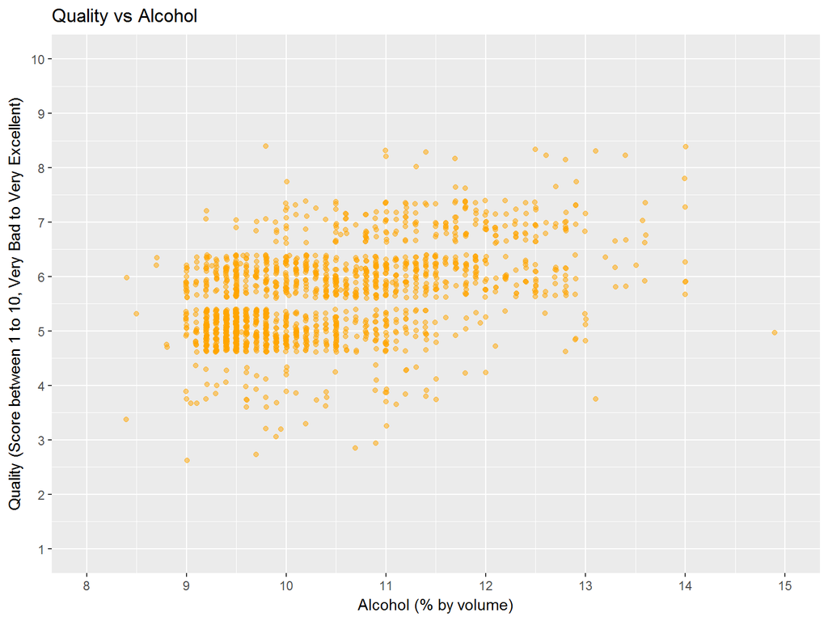

### Description Two

This suggests that if based purely on alcohol values, keeping the range from 9.8 to 14 has a higher possibility of generating higher quality red wines.

### Plot Three

[figure not shown]

### Description Three

Using alcohol as the main variable, the remaining correlated variables were added to the plots as color scales to determine their effects. From there, it appears that the variables need to be in a certain range in addition to alcohol to result in quality 8 red wines.

Ranges are:

- Alcohol: 9.8 to 14
- Sulphates: 0.63 to 1.10
- Citric Acid: 0.03 to 0.72
- Fixed Acidity: 5 to 12.6
- Residual Sugar: 1.4 to 6.40

# Reflection

Dataset contained information about 1599 red wines across 12 variables.

I started by plotting histograms of all the variables to get a feel of how the data looked like. Initially, I thought that residual sugar would have the most impact on quality as it had the highest count of 156 at 2.0 meaning that it is present in around 10% of the red wines.

However after plotting out and subsetting the data, it was clear that this was not the case as the counts were mainly for quality 5 and 6.

Next, I plotted the correlation matrix and table. They showed that quality had relationships with alcohol (~0.48), sulphates (~0.26), citric acid (~0.23), fixed acidity (~0.12) and residual sugar (~0.01). After plotting scatterplots of quality against each of the variables above, it was observed that alcohol has the best relationship though limited and it was selected as the primary attribute.

Summary statistics of quality vs the other correlated variables were created and from there, the mean variable values were determined.

Lastly, I moved to creating scatterplots of quality vs alcohol and using the other variables to color-code the points. Based on the color, a range of the varibles creating quality 8 was noted.

Limitations/Difficulties:

- While transforming the axis using Log10, I noticed that the scale does not seem to fit properly. In the “Historgram Log10 of Residual Sugar” plot, the x-axis does not seem to scale equally
- Scale Log10 values seem different from calculation. While transforming the “Histogram of Total Sulfur Dioxide”, scale_log10 values showed more than 100 but using “rwq$log10_tsd <- log10(rwq$total.sulfur.dioxide)”, the maximum value was only around 2.460898
- Creating a prediction for quality was hard as it was evaluated/determined by humans where results may not be same if measured again
- I was unable to include the remaining variables in the analysis in any meaning manner
- Lack of a strong variable correlation with quality made the analysis much harder
- Unable to create a new variable from existing ones (For example, using x, y and z from diamonds to form volume) as such relationships does not seem to exist in the dataset